# House Price

Yitian Fu

11/11/2021

# 1. Introduction to the data

All the information about this project comes from kaggle: https://www.kaggle.com/c/house-prices-advanced-regression-techniques/submissions. In this project, I want to make predictions about the house price by knowing the details about the house. For example, when the house built and how many bathrooms it has can affect the house price. There are two files: train and test. They have the same amount of predictors, the only difference is the train data has the SalePrice of each observed house, but the test data does not have. So in this project, I would use the train data to fit lots of different models, and then make predictions for observations in the test.

# 2. Explain the raw data

There are 1459 observation in the test data with 80 predictors. There are 1460 observations in the train data with 80 predictors and 1 response variable. The two data files have some missing values. Before I build models and make predictions, I will do a data cleaning to fill the missing data.

# 3. Explain how to cleaned the data

First, I combined train and test together because I want to deal them together. Then I calculate the proportion of the missing values in each column, if there are more than 5% missing data in that column, I will delete that column. Next, I found some variables are factors and they were showed as characters in the data frame, so I just convert them to factors. Finally, I use the `missForest` package to fill the missing values.

```r
train<-read.csv("train.csv")
test<-read.csv("test.csv")
test$SalePrice<-rep(0,nrow(test))
```

```r
#combine them to do data cleaning together
all.data<-rbind(train,test)
# if that variable has more than 5% missing data, then delete it
for (i in 1:81){
  x<-sum(is.na(all.data[,i]))/2919
  if (x>=0.05){
    print(colnames(all.data[i]))
  }
}
```

```
## [1] "LotFrontage"
## [1] "Alley"
## [1] "FireplaceQu"
## [1] "GarageType"
## [1] "GarageYrBlt"
## [1] "GarageFinish"
## [1] "GarageQual"
## [1] "GarageCond"
## [1] "PoolQC"
## [1] "Fence"
## [1] "MiscFeature"
```

```r
all.data.1<-all.data[,-81]
all.data.1<- subset(all.data.1, select = -c(LotFrontage,Alley,FireplaceQu,GarageType,GarageYrBlt,GarageFinish,GarageQual,GarageCond,PoolQC,Fence,MiscFeature))
```

```r
all.data.1[sapply(all.data.1, is.character)] <- lapply(all.data.1[sapply(all.data.1, is.character)], as.factor)
```

```r
library(missForest)
set.seed(100)
all.data.1.miss <- prodNA(all.data.1, noNA = 0.2)
forest_data <- missForest(all.data.1.miss, verbose = TRUE)
```

```
##   missForest iteration 1 in progress...done!
##     estimated error(s): 0.4633298 0.1330233
##     difference(s): 0.0161101 0.04384056
##     time: 249.803 seconds
##
##   missForest iteration 2 in progress...done!
##     estimated error(s): 0.4670727 0.1251901
##     difference(s): 0.000954897 0.006700522
##     time: 251.378 seconds
##
##   missForest iteration 3 in progress...done!
##     estimated error(s): 0.4552202 0.1245478
##     difference(s): 0.0009511233 0.005723153
##     time: 243.805 seconds
##
##   missForest iteration 4 in progress...done!
##     estimated error(s): 0.4582062 0.1252552
##     difference(s): 0.000894084 0.005481329
##     time: 227.509 seconds
##
##   missForest iteration 5 in progress...done!
##     estimated error(s): 0.4680887 0.1245071
##     difference(s): 0.001141476 0.005551861
##     time: 247.26 seconds
```

```r
final_data<-forest_data$ximp
#final_data_file<-write.csv(final_data, "final_data_file.csv")
sum(is.na(final_data))
```

```
## [1] 0
```

```r
summary(final_data)
```

```
##        Id           MSSubClass        MSZoning       LotArea        Street
##  Min.   :   1.0   Min.   : 20.00   C (all):  24   Min.   :  1470   Grvl:  12
##  1st Qu.: 923.5   1st Qu.: 20.00   FV     : 133   1st Qu.:  7730   Pave:2907
##  Median :1452.0   Median : 50.00   RH     :  20   Median :  9600
##  Mean   :1469.2   Mean   : 56.93   RL     :2274   Mean   : 10168
##  3rd Qu.:2028.5   3rd Qu.: 70.00   RM     : 468   3rd Qu.: 11482
##  Max.   :2919.0   Max.   :190.00                  Max.   :164660
##
##  LotShape   LandContour  Utilities      LotConfig    LandSlope   Neighborhood
##  IR1: 964   Bnk:  96    AllPub:2918   Corner : 395   Gtl:2805   NAmes  : 463
##  IR2:  56   HLS: 100    NoSeWa:   1   CulDSac: 154   Mod: 102   CollgCr: 275
##  IR3:  15   Low:  51                  FR2    :  68   Sev:  12   OldTown: 258
##  Reg:1884   Lvl:2672                  FR3    :  10              Edwards: 184
##                                       Inside :2292              NridgHt: 178
##                                                                 Somerst: 172
##                                                                 (Other):1389
##    Condition1     Condition2     BldgType      HouseStyle    OverallQual
##  Norm   :2592   Norm   :2896   1Fam  :2434   1Story :1485   Min.   : 1.000
##  Feedr  : 126   Feedr  :  11   2fmCon:  53   2Story : 883   1st Qu.: 5.000
##  Artery :  78   Artery :   5   Duplex: 109   1.5Fin : 306   Median : 6.000
##  RRAn   :  38   PosA   :   3   Twnhs :  97   SLvl   : 121   Mean   : 6.089
##  PosN   :  29   PosN   :   2   TwnhsE: 226   SFoyer :  80   3rd Qu.: 7.000
##  RRAe   :  23   RRAe   :   1                 2.5Unf :  22   Max.   :10.000
##  (Other):  33   (Other):   1                 (Other):  22
##   OverallCond      YearBuilt     YearRemodAdd    RoofStyle       RoofMatl
##  Min.   :1.000   Min.   :1875   Min.   :1950   Flat   :  17   CompShg:2888
##  1st Qu.:5.000   1st Qu.:1954   1st Qu.:1967   Gable  :2369   Tar&Grv:  17
##  Median :5.000   Median :1972   Median :1991   Gambrel:  17   WdShake:   6
##  Mean   :5.567   Mean   :1971   Mean   :1984   Hip    : 502   WdShngl:   6
##  3rd Qu.:6.000   3rd Qu.:2000   3rd Qu.:2003   Mansard:  10   ClyTile:   1
##  Max.   :9.000   Max.   :2010   Max.   :2010   Shed   :   4   Membran:   1
##                                                               (Other):   0
##   Exterior1st    Exterior2nd     MasVnrType     MasVnrArea     ExterQual
##  VinylSd:1012   VinylSd:1014   BrkCmn :  19   Min.   :   0.0   Ex: 103
##  Wd Sdng: 465   MetalSd: 435   BrkFace: 890   1st Qu.:   0.0   Fa:  31
##  HdBoard: 449   Wd Sdng: 435   None   :1752   Median :   3.8   Gd: 978
##  MetalSd: 434   HdBoard: 413   Stone  : 258   Mean   : 104.7   TA:1807
##  Plywood: 229   Plywood: 261                  3rd Qu.: 170.0
##  CemntBd: 123   CmentBd: 121                  Max.   :1600.0
##  (Other): 207   (Other): 240
```

[output cut: 65 more lines]

```
##  Min.   :    0.00   Min.   : 1.00   Min.   :2006   WD     :2557
##  1st Qu.:    0.00   1st Qu.: 5.00   1st Qu.:2007   New    : 232
##  Median :    0.00   Median : 6.00   Median :2008   COD    :  76
##  Mean   :   57.67   Mean   : 6.19   Mean   :2008   ConLD  :  20
##  3rd Qu.:    0.00   3rd Qu.: 7.00   3rd Qu.:2009   CWD    :  10
##  Max.   :17000.00   Max.   :12.00   Max.   :2010   ConLw  :   8
##                                                    (Other):  16
##  SaleCondition
##  Abnorml: 157
##  AdjLand:   9
##  Alloca :  20
##  Family :  37
##  Normal :2463
##  Partial: 233
##
```

```r
final_data.1 <- model.matrix( ~ ., data=final_data)[,-1]
sum(is.na(final_data.1))
```

```
## [1] 0
```

# Machine Learning Methods

## KNN Method

```r
#scale the data
scaled_data<-scale(final_data.1)
na_column<-c()
for (i in (1:216)){
  if (sum(is.na(scaled_data[,i]))!=0) {
    na_column<-append(na_column,i)
  }
}
scaled_data_1<-scaled_data[,-na_column]
sum(is.na(scaled_data_1))
```

```
## [1] 0
```

```r
X.scaled.train <- scaled_data_1[1:nrow(train),]
y.train<-train$SalePrice
x.scaled.test<-scaled_data_1[(nrow(train)+1):nrow(scaled_data_1),]
```

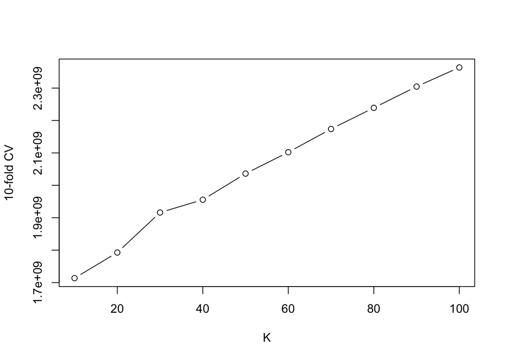

```r
# choose k by 10 fold CV
library(FNN)
set.seed(10) ## the seed can be arbitrary but we use 10 for the sake of consistency
fold.index <- cut(sample(1:nrow(X.scaled.train)), breaks=10, labels=FALSE)
K.vt <- c(10,20,30,40,50,60,70,80,90,100)
error.k <- rep(0, length(K.vt))
counter <- 0
for(k in K.vt){
counter <- counter + 1 # counter for error.k
mse <- rep(0,10) # initialize an mse object to record the MSE for each fold
for(i in 1:10){
pred.out <- knn.reg(X.scaled.train[fold.index!=i,], X.scaled.train[fold.index==i,],
train$SalePrice[fold.index!=i], k=k)
mse[i] <- mean((pred.out$pred - train$SalePrice[fold.index==i])^2)
}
error.k[counter] <- sum(mse)/10
}
plot(c(10,20,30,40,50,60,70,80,90,100), error.k, type="b", xlab="K", ylab="10-fold CV")
```

### CV MSE for KNN

```r
print(error.k)
```

```
##  [1] 1713765351 1792753524 1916151737 1955568288 2036184979 2102114623
##  [7] 2173820324 2239018053 2304601388 2363532384
```

```r
#choose k=10 because it has the smallest MSE
```

```r
knn_prediction <- knn.reg(train = X.scaled.train,
                    test = x.scaled.test,
                    y = y.train,
                    k = 10)$pred
# ID<- 1461:2919
# SalePrice <- knn_prediction
# knn_prediction <- data.frame(ID,SalePrice)
# write.csv(knn_prediction,"knn_prediction.csv", row.names = FALSE)
```

## Linear Regression

### Fit a linear regression model using all the predictors except Id

```r
whole_train<-final_data[1:1460,-1]
whole_train$SalePrice<-y.train
whole_train<-as.data.frame(whole_train)
whole_test<-final_data[1461:2919,-1]
whole_test<-as.data.frame(whole_test)
lm.fit<- lm(SalePrice~., data = whole_train)
#summary(lm.fit)
```

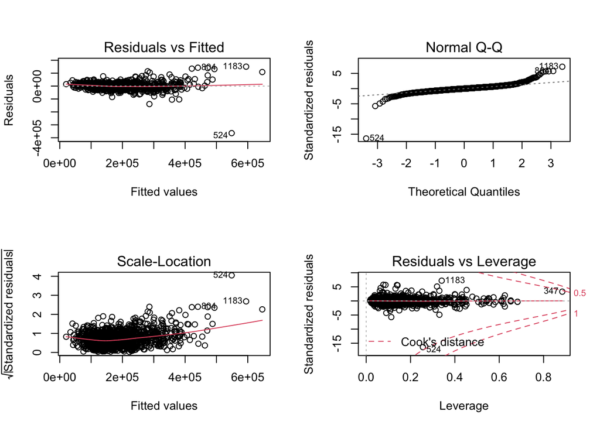

```r
par(mfrow=c(2,2))
plot(lm.fit)
```

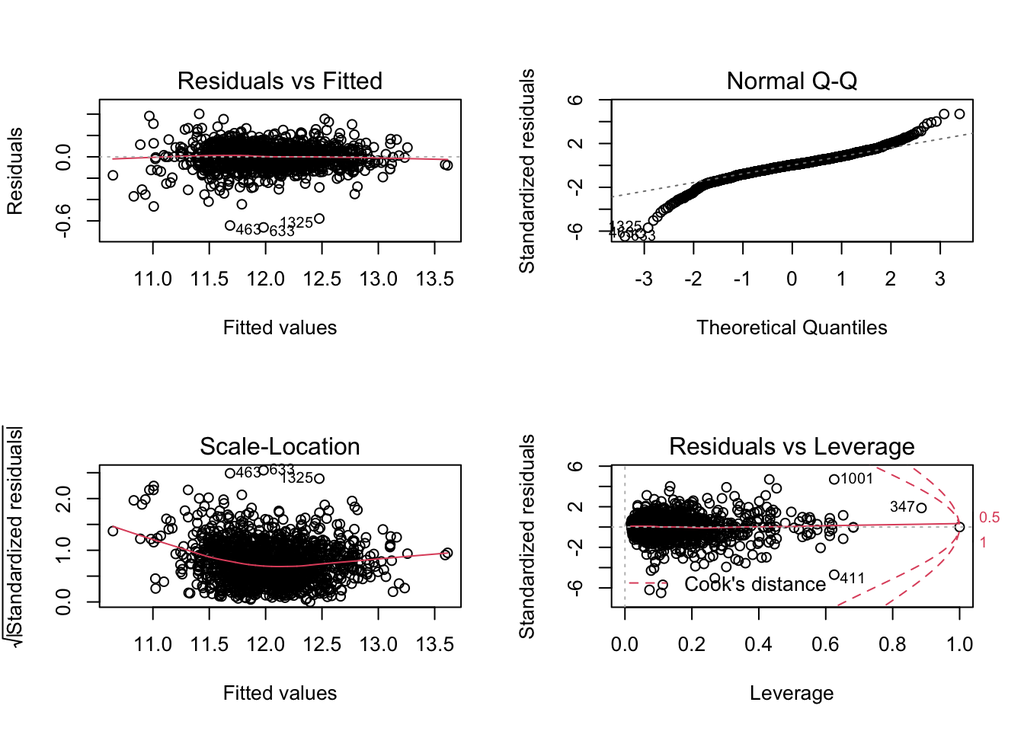

```r
new.lm.fit<- lm(log(SalePrice)~., data = whole_train[-524,])
par(mfrow=c(2,2))
plot(new.lm.fit)
```

```r
summary(new.lm.fit)
```

```
##
## Call:
## lm(formula = log(SalePrice) ~ ., data = whole_train[-524, ])
##
## Residuals:
##      Min       1Q   Median       3Q      Max
## -0.66082 -0.05017  0.00341  0.05634  0.40234
##
## Coefficients: (1 not defined because of singularities)
##                        Estimate Std. Error t value Pr(>|t|)
## (Intercept)           8.192e+00  5.540e+00   1.479 0.139497
## MSSubClass           -5.593e-04  3.836e-04  -1.458 0.145033
## MSZoningFV            4.849e-01  5.804e-02   8.354  < 2e-16 ***
## MSZoningRH            4.428e-01  5.709e-02   7.755 1.82e-14 ***
## MSZoningRL            4.517e-01  4.900e-02   9.217  < 2e-16 ***
## MSZoningRM            4.142e-01  4.564e-02   9.074  < 2e-16 ***
## LotArea               2.210e-06  5.707e-07   3.872 0.000113 ***
## StreetPave            9.572e-02  5.816e-02   1.646 0.100065
## LotShapeIR2           3.190e-02  2.285e-02   1.396 0.162823
## LotShapeIR3           1.744e-02  3.993e-02   0.437 0.662345
## LotShapeReg           6.460e-03  7.578e-03   0.852 0.394129
## LandContourHLS        1.559e-02  2.707e-02   0.576 0.564614
## LandContourLow       -3.981e-02  3.108e-02  -1.281 0.200555
## LandContourLvl        5.804e-03  1.935e-02   0.300 0.764296
## UtilitiesNoSeWa      -2.703e-01  1.218e-01  -2.218 0.026710 *
## LotConfigCulDSac      2.456e-02  1.606e-02   1.529 0.126566
## LotConfigFR2         -4.880e-02  2.066e-02  -2.362 0.018328 *
## LotConfigFR3         -3.297e-02  5.967e-02  -0.553 0.580647
## LotConfigInside      -9.543e-03  8.914e-03  -1.071 0.284594
## LandSlopeMod          3.169e-02  1.836e-02   1.726 0.084507 .
## LandSlopeSev          7.894e-02  5.066e-02   1.558 0.119385
## NeighborhoodBlueste   4.470e-03  8.987e-02   0.050 0.960335
## NeighborhoodBrDale   -3.556e-02  5.270e-02  -0.675 0.500020
## NeighborhoodBrkSide   6.898e-02  4.636e-02   1.488 0.137041
## NeighborhoodClearCr   2.648e-02  4.502e-02   0.588 0.556544
## NeighborhoodCollgCr   6.567e-03  3.437e-02   0.191 0.848515
## NeighborhoodCrawfor   1.496e-01  4.079e-02   3.669 0.000254 ***
## NeighborhoodEdwards  -3.146e-02  3.836e-02  -0.820 0.412241
## NeighborhoodGilbert   1.000e-02  3.677e-02   0.272 0.785632
## NeighborhoodIDOTRR    4.756e-02  5.273e-02   0.902 0.367217
```

[output cut: 171 more lines]

```
## SaleTypeCWD          -1.276e-01  9.103e-02  -1.401 0.161380
## SaleTypeNew           1.499e-01  5.724e-02   2.618 0.008952 **
## SaleTypeOth           3.648e-02  6.740e-02   0.541 0.588435
## SaleTypeWD           -1.793e-02  2.072e-02  -0.865 0.387102
## SaleConditionAdjLand  1.923e-01  7.896e-02   2.436 0.015003 *
## SaleConditionAlloca   2.846e-02  4.240e-02   0.671 0.502188
## SaleConditionFamily   2.738e-02  3.105e-02   0.882 0.378060
## SaleConditionNormal   6.136e-02  1.434e-02   4.278 2.03e-05 ***
## SaleConditionPartial -7.432e-02  5.496e-02  -1.352 0.176512
## ---
## Signif. codes:  0 '***' 0.001 '**' 0.01 '*' 0.05 '.' 0.1 ' ' 1
##
## Residual standard error: 0.1078 on 1250 degrees of freedom
## Multiple R-squared:  0.9376, Adjusted R-squared:  0.9272
## F-statistic: 90.25 on 208 and 1250 DF,  p-value: < 2.2e-16
```

### CV MSE

```r
# choose k by 10 fold CV
whole_train.new<-whole_train[-524,]
whole_train.new<-model.matrix( ~ ., data=whole_train.new)[,-1]
whole_train.new<- as.data.frame(whole_train.new)
whole_test<-model.matrix( ~ ., data=whole_test)[,-1]
whole_test<- as.data.frame(whole_test)
whole_test.new<-final_data[1461:2919,-1]

fold.index <- cut(sample(1:nrow(X.scaled.train)), breaks=10, labels=FALSE)
error.k <- rep(0, length(K.vt))
mse <- rep(0,10)
for (i in 1:10){
  lm.fit.cv<- lm(log(SalePrice)~., data = whole_train.new[fold.index != i,])
  pred.cv <- predict(lm.fit.cv, whole_train.new[fold.index == i,])
  mse[i] <- mean((exp(pred.cv) - whole_train.new$SalePrice[fold.index==i])^2)
}
print(mean(mse, na.rm=TRUE))
```

```
## [1] 1988718363
```

```r
new.lm.fit<- lm(log(SalePrice)~., data = whole_train.new)
lm.pred<- predict(new.lm.fit, newdata = whole_test)
# Id <- 1461:2919
# SalePrice <- exp(lm.pred)
# linear_regression <- data.frame(Id,SalePrice)
# write.csv(linear_regression,"linear_regression.csv", row.names = FALSE)
```

## Ridge

```r
library(glmnet)
final_data.1 <- model.matrix( ~ ., data=final_data)[,-1]
X<-final_data.1[1:1460,]
test<-final_data.1[1461:2919, ]
ridge.model<- glmnet(X,y.train, alpha = 0)
```

### ridge CV MSE

```r
cv.out<- cv.glmnet(X,y.train, alpha = 0, nfolds = 10)
cv.out
```

```
##
## Call:  cv.glmnet(x = X, y = y.train, nfolds = 10, alpha = 0)
##
## Measure: Mean-Squared Error
##
##     Lambda Index   Measure        SE Nonzero
## min  25489    85 1.132e+09 308611974     210
## 1se 216595    62 1.430e+09 245574556     210
```

```r
cv.out$lambda.min
```

```
## [1] 25489.12
```

```r
min(cv.out$cvm)
```

```
## [1] 1132386827
```

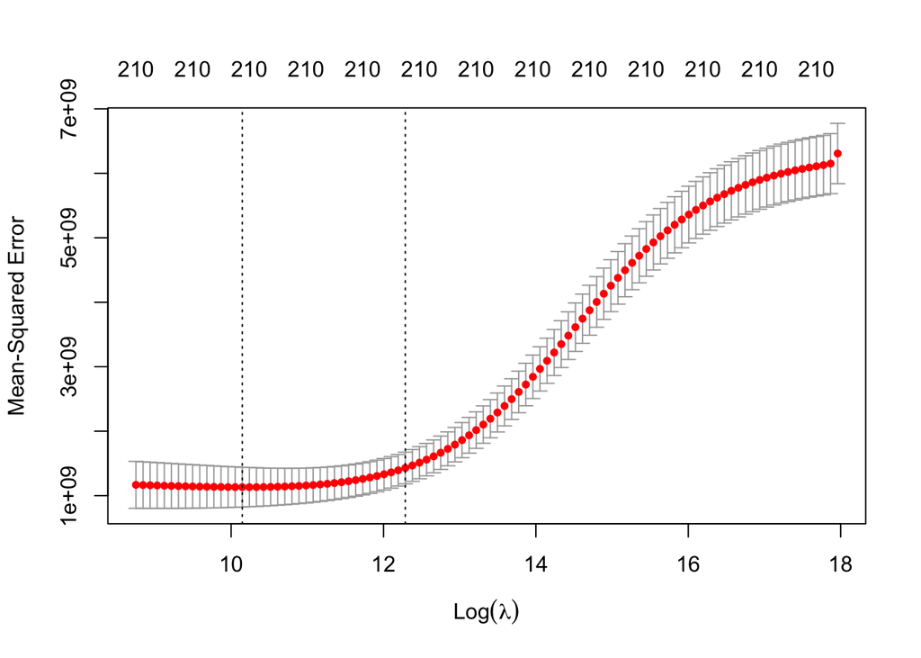

```r
plot(cv.out)
```

```r
coef(ridge.model, s=cv.out$lambda.min)
```

```
## 217 x 1 sparse Matrix of class "dgCMatrix"
##                                 s1
## (Intercept)          -6.577676e+05
## Id                   -1.588078e-01
## MSSubClass           -7.061619e+01
## MSZoningFV            4.549387e+03
## MSZoningRH           -1.595267e+02
## MSZoningRL            3.325857e+03
## MSZoningRM           -2.302951e+03
## LotArea               1.711580e-01
## StreetPave            1.387957e+04
## LotShapeIR2           5.900273e+03
## LotShapeIR3          -1.439107e+04
## LotShapeReg          -4.489979e+02
## LandContourHLS        1.100069e+04
## LandContourLow        1.769390e+03
## LandContourLvl        6.309006e+03
## UtilitiesNoSeWa      -4.407844e+04
## LotConfigCulDSac      1.068350e+04
## LotConfigFR2         -7.396958e+03
## LotConfigFR3         -1.045930e+04
## LotConfigInside      -1.701916e+03
## LandSlopeMod          6.792076e+03
## LandSlopeSev          1.690303e+04
## NeighborhoodBlueste   2.970276e+03
## NeighborhoodBrDale    4.584825e+02
## NeighborhoodBrkSide   2.517083e+03
## NeighborhoodClearCr  -7.663597e+02
## NeighborhoodCollgCr  -4.053435e+03
## NeighborhoodCrawfor   1.468837e+04
## NeighborhoodEdwards  -9.880328e+03
## NeighborhoodGilbert  -6.432006e+03
## NeighborhoodIDOTRR   -3.225332e+03
## NeighborhoodMeadowV  -7.849523e+03
## NeighborhoodMitchel  -8.045123e+03
## NeighborhoodNAmes    -4.801236e+03
## NeighborhoodNoRidge   3.280827e+04
## NeighborhoodNPkVill   4.272739e+03
## NeighborhoodNridgHt   2.502630e+04
## NeighborhoodNWAmes   -7.427111e+03
```

[output cut: 164 more lines]

```
## MoSold               -1.664373e+02
## YrSold                6.473346e+01
## SaleTypeCon           1.766618e+04
## SaleTypeConLD        -4.809574e+02
## SaleTypeConLI         1.412912e+03
## SaleTypeConLw        -9.985784e+02
## SaleTypeCWD          -1.758732e+04
## SaleTypeNew           7.373808e+03
## SaleTypeOth           2.242612e+03
## SaleTypeWD           -1.600587e+03
## SaleConditionAdjLand  1.306834e+04
## SaleConditionAlloca  -4.324277e+03
## SaleConditionFamily  -6.084285e+03
## SaleConditionNormal   3.787317e+03
## SaleConditionPartial  5.795987e+03
```

```r
ridge<-predict(ridge.model, s = cv.out$lambda.min, newx = test)
# Id <- 1461:2919
# SalePrice <- ridge
# ridge <- data.frame(Id,SalePrice)
# names(ridge) <- c("Id","SalePrice")
# write.csv(ridge,"ridge.csv", row.names = FALSE)
```

## Lasso

```r
lasso.model<- glmnet(X,y.train, alpha = 1)
cv.out<- cv.glmnet(X,y.train, alpha = 1, nfolds = 10)
cv.out
```

```
##
## Call:  cv.glmnet(x = X, y = y.train, nfolds = 10, alpha = 1)
##
## Measure: Mean-Squared Error
##
##     Lambda Index   Measure        SE Nonzero
## min    603    51 1.033e+09 237355885     102
## 1se   4252    30 1.267e+09 279489268      25
```

```r
cv.out$lambda.min
```

```
## [1] 602.6875
```

### Lasso CV MSE

```r
min(cv.out$cvm)
```

```
## [1] 1032728232
```

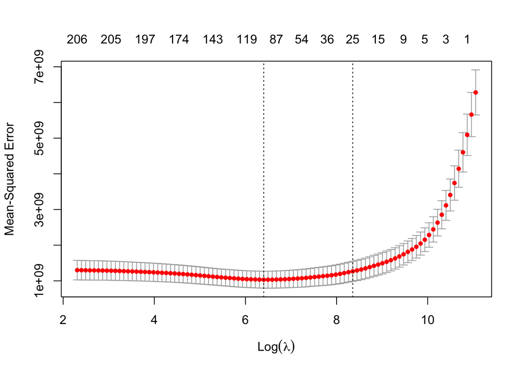

```r
plot(cv.out)
```

I think lasso is better for model interpretation part and lasso has smaller training MSE.

```r
coef(lasso.model, s=cv.out$lambda.min)
```

```
## 217 x 1 sparse Matrix of class "dgCMatrix"
##                                 s1
## (Intercept)          -7.585505e+05
## Id                    .
## MSSubClass           -1.131691e+02
## MSZoningFV            2.730506e+00
## MSZoningRH            .
## MSZoningRL            8.358098e+02
## MSZoningRM            .
## LotArea               4.638591e-02
## StreetPave            1.974179e+03
## LotShapeIR2           2.820635e+03
## LotShapeIR3          -6.234105e+03
## LotShapeReg           .
## LandContourHLS        7.357474e+03
## LandContourLow        .
## LandContourLvl        5.385224e+03
## UtilitiesNoSeWa      -2.227259e+04
## LotConfigCulDSac      1.256361e+04
## LotConfigFR2         -2.666037e+03
## LotConfigFR3         -3.166283e+03
## LotConfigInside       .
## LandSlopeMod          5.081321e+03
## LandSlopeSev          2.466895e+04
## NeighborhoodBlueste   .
## NeighborhoodBrDale    .
## NeighborhoodBrkSide   3.421916e+02
## NeighborhoodClearCr   .
## NeighborhoodCollgCr   .
## NeighborhoodCrawfor   1.830717e+04
## NeighborhoodEdwards  -5.290374e+03
## NeighborhoodGilbert   .
## NeighborhoodIDOTRR    .
## NeighborhoodMeadowV   .
## NeighborhoodMitchel  -2.747261e+03
## NeighborhoodNAmes     .
## NeighborhoodNoRidge   3.776443e+04
## NeighborhoodNPkVill   2.957067e+03
## NeighborhoodNridgHt   3.020682e+04
## NeighborhoodNWAmes   -5.100060e+03
```

[output cut: 164 more lines]

```
## MoSold               -7.723559e+01
## YrSold                .
## SaleTypeCon           1.575815e+04
## SaleTypeConLD         .
## SaleTypeConLI         .
## SaleTypeConLw         .
## SaleTypeCWD          -1.410034e+04
## SaleTypeNew           1.405467e+04
## SaleTypeOth           .
## SaleTypeWD            .
## SaleConditionAdjLand  3.029491e+03
## SaleConditionAlloca  -1.867594e+01
## SaleConditionFamily   .
## SaleConditionNormal   4.272014e+03
## SaleConditionPartial  .
```

```r
lasso.pred<-predict(lasso.model, s= cv.out$lambda.min, newx = test)
# Id <- 1461:2919
# SalePrice <- lasso.pred
# lasso <- data.frame(Id,SalePrice)
# names(lasso) <- c("Id","SalePrice")
# write.csv(lasso,"lasso .csv", row.names = FALSE)
```

## Regression Trees

```r
library(tree)
new_data<-whole_train[-524,]
tree.fit<-tree(log(SalePrice)~.,data= whole_train)
tree.fit
```

```
## node), split, n, deviance, yval
##       * denotes terminal node
##
##  1) root 1460 232.800 12.02
##    2) OverallQual < 6.145 913  74.310 11.81
##      4) Neighborhood: BrDale,BrkSide,Edwards,IDOTRR,MeadowV,OldTown 301  26.210 11.60
##        8) GrLivArea < 1112.5 118   9.202 11.42
##         16) OverallQual < 4.5 51   4.456 11.24 *
##         17) OverallQual > 4.5 67   1.857 11.55 *
##        9) GrLivArea > 1112.5 183  10.370 11.72 *
##      5) Neighborhood: Blueste,ClearCr,CollgCr,Crawfor,Gilbert,Mitchel,NAmes,NPkVill,NridgHt,NWAmes,Sawyer,SawyerW,Somerst,SWISU,Timber,Veenker 612  27.810 11.92
##       10) GrLivArea < 1250.5 286   7.860 11.79 *
##       11) GrLivArea > 1250.5 326  10.680 12.03
##         22) Neighborhood: Blueste,Mitchel,NAmes,NPkVill,Sawyer,SawyerW,SWISU 170   4.184 11.94 *
##         23) Neighborhood: ClearCr,CollgCr,Crawfor,Gilbert,NridgHt,NWAmes,Somerst,Timber,Veenker 156   3.736 12.13 *
##    3) OverallQual > 6.145 547  49.630 12.38
##      6) OverallQual < 7.42 324  14.120 12.23
##       12) GrLivArea < 1891.89 233   7.707 12.16 *
##       13) GrLivArea > 1891.89 91   3.016 12.39 *
##      7) OverallQual > 7.42 223  18.060 12.59
##       14) OverallQual < 8.08 159   8.113 12.50 *
##       15) OverallQual > 8.08 64   4.740 12.83 *
```

```r
summary(tree.fit)
```

```
##
## Regression tree:
## tree(formula = log(SalePrice) ~ ., data = whole_train)
## Variables actually used in tree construction:
## [1] "OverallQual"  "Neighborhood" "GrLivArea"
## Number of terminal nodes:  10
## Residual mean deviance:  0.03865 = 56.04 / 1450
## Distribution of residuals:
##      Min.   1st Qu.    Median      Mean   3rd Qu.      Max.
## -1.123000 -0.103300  0.008479  0.000000  0.112300  0.733600
```

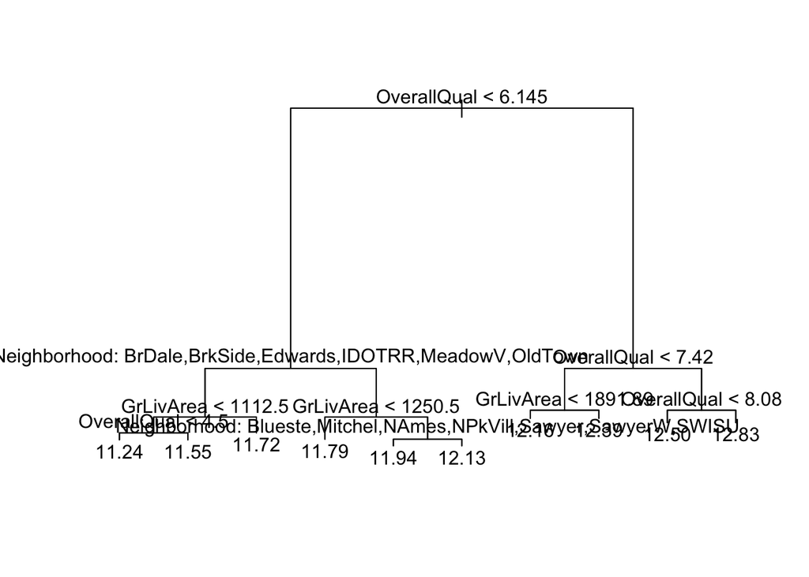

```r
par(mfrow=c(1,1))
plot(tree.fit)
text(tree.fit, pretty = 0)
```

### Explain the model

When OverallQuall is smaller tan 6.145, it goes left, otherwise it goes right.

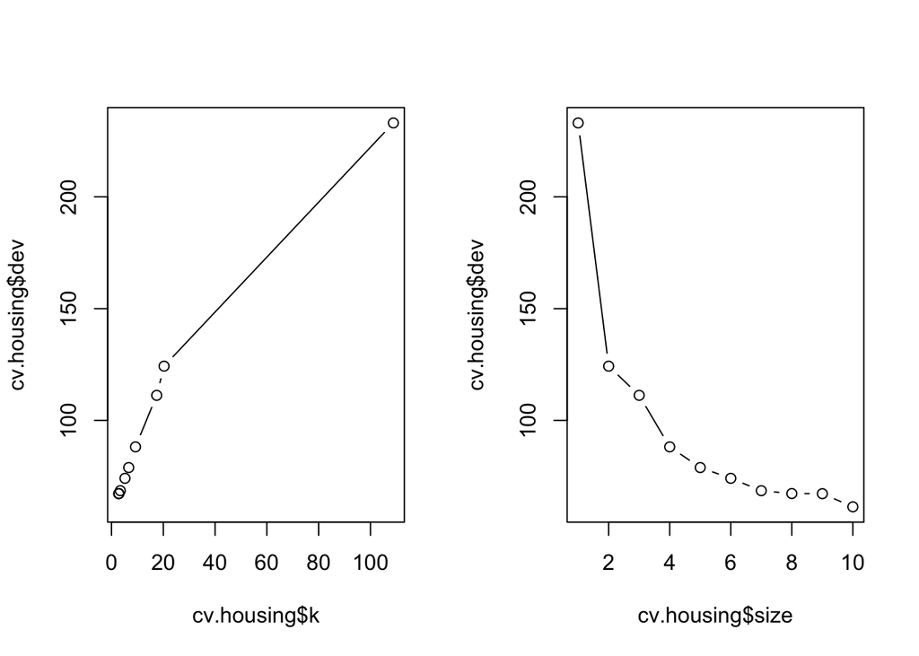

```r
set.seed(481)
cv.housing<-cv.tree(tree.fit,K=10)
par(mfrow=c(1,2))
plot(cv.housing$k,cv.housing$dev, type="b")

plot(cv.housing$size,cv.housing$dev, type="b")
```

### Choose parameter by cv

```r
best.size<-cv.housing$size[which.min(cv.housing$dev)]
best.size
```

```
## [1] 10
```

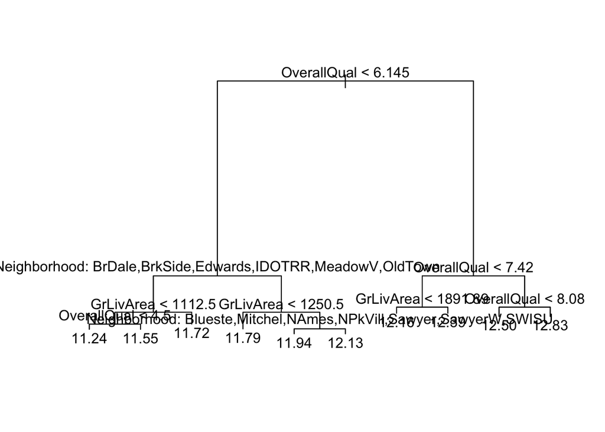

```r
prune.housing<-prune.tree(tree.fit, best=best.size)
par(mfrow=c(1,1))
plot(prune.housing)
text(prune.housing, pretty = 0)
```

### prediction

```r
housing.pred<-predict(prune.housing,newdata=whole_test.new)
# Id <- 1461:2919
# SalePrice <- exp(housing.pred)
# regressiontree <- data.frame(Id,SalePrice)
# names(regressiontree) <- c("Id","SalePrice")
# write.csv(regressiontree,"regressiontree .csv", row.names = FALSE)
```

## Bagging

```r
library(randomForest)
bag.fit<-randomForest(log(SalePrice)~.,data=new_data, mytry=68, importance=TRUE,ntree=5000)
bag.fit
```

```
##
## Call:
##  randomForest(formula = log(SalePrice) ~ ., data = new_data, mytry = 68,      importance = TRUE, ntree = 5000)
##                Type of random forest: regression
##                      Number of trees: 5000
## No. of variables tried at each split: 22
##
##           Mean of squared residuals: 0.01856966
##                     % Var explained: 88.36
```

### choose tuning parameter and interpretation

```r
importance(bag.fit)
```

```
##                   %IncMSE IncNodePurity
## MSSubClass     41.1025567  7.927265e-01
## MSZoning       30.2553878  1.277217e+00
## LotArea        52.5551910  2.903730e+00
## Street         -1.4112730  1.620831e-02
## LotShape       12.1361579  2.064821e-01
## LandContour     2.6425871  2.153376e-01
## Utilities       0.0000000  4.656079e-04
## LotConfig       2.9151288  2.138712e-01
## LandSlope       6.2303997  1.141173e-01
## Neighborhood  105.4372007  3.347747e+01
## Condition1      4.2387636  2.247860e-01
## Condition2     -1.7499190  1.248113e-02
## BldgType       23.8988254  2.498398e-01
## HouseStyle     28.0266993  5.177605e-01
## OverallQual    80.1861163  5.580129e+01
## OverallCond    47.0157586  1.617002e+00
## YearBuilt      35.0722021  8.171342e+00
## YearRemodAdd   41.1301397  2.300708e+00
## RoofStyle       5.3552424  2.294208e-01
## RoofMatl       -2.9973393  4.907591e-02
## Exterior1st    32.8125679  1.612414e+00
## Exterior2nd    32.5441624  1.703168e+00
## MasVnrType     16.9111781  1.754310e-01
## MasVnrArea     22.1680289  9.869767e-01
## ExterQual      39.4286269  1.849954e+01
## ExterCond      -0.6553219  1.574793e-01
## Foundation     15.8826178  6.575031e-01
## BsmtQual       22.4994159  4.667774e+00
## BsmtCond        2.8461801  1.258882e-01
## BsmtExposure   22.9491415  4.761414e-01
## BsmtFinType1   42.8047654  1.088391e+00
## BsmtFinSF1     71.5750613  3.221393e+00
## BsmtFinType2   -0.5286038  9.741603e-02
## BsmtFinSF2      6.3713087  2.501449e-01
## BsmtUnfSF      31.5348730  9.916225e-01
## TotalBsmtSF    85.3108128  8.157569e+00
## Heating        -2.3354640  7.206249e-02
## HeatingQC      15.0470967  4.901623e-01
## CentralAir     17.6043630  1.961981e+00
```

[output cut: 14 more lines]

```
## Fireplaces     48.3371519  3.494045e+00
## GarageCars     53.6116128  1.056022e+01
## GarageArea     60.8639923  8.298368e+00
## PavedDrive      7.7268710  3.286152e-01
## WoodDeckSF     22.5831626  6.966226e-01
## OpenPorchSF    26.5519926  7.762843e-01
## EnclosedPorch   8.2825855  4.626987e-01
## X3SsnPorch      7.3116966  2.396868e-01
## ScreenPorch     7.3722140  2.595034e-01
## PoolArea        0.2103005  2.617887e-01
## MiscVal        -1.8152013  2.546814e-01
## MoSold         -2.3683871  6.515391e-01
## YrSold          1.5345443  4.264393e-01
## SaleType        2.8130359  1.511266e-01
## SaleCondition   2.3651432  5.827895e-01
```

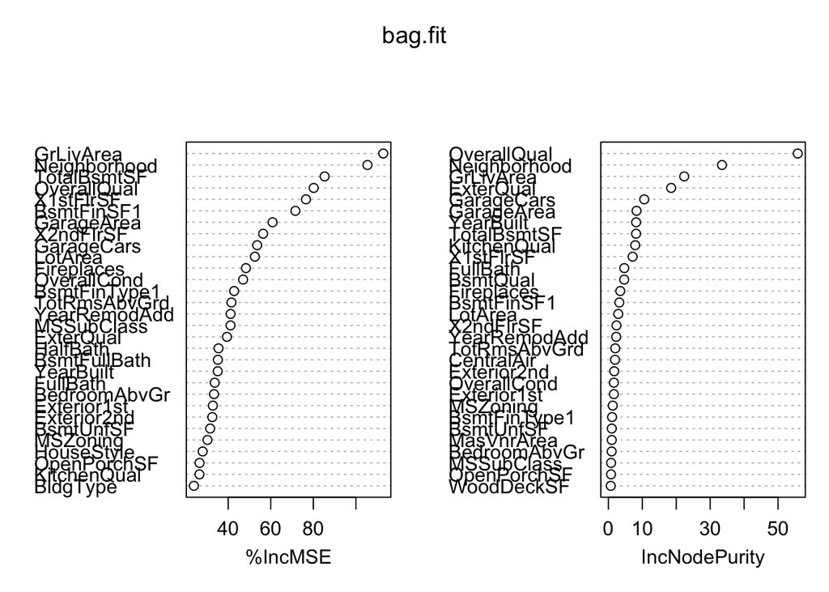

```r
varImpPlot(bag.fit)
```

### prediction

```r
bag.pred<-predict(bag.fit,newdata=whole_test.new)
Id <- 1461:2919
SalePrice <- exp(bag.pred)
bagging <- data.frame(Id,SalePrice)
names(bagging) <- c("Id","SalePrice")
write.csv(bagging,"bagging .csv", row.names = FALSE)
```

## Random Forest

```r
rf.fit<-randomForest(log(SalePrice)~.,data=whole_train,mytry=round(sqrt(68)),importance=TRUE, n.tree=5000)
rf.fit
```

```
##
## Call:
##  randomForest(formula = log(SalePrice) ~ ., data = whole_train,      mytry = round(sqrt(68)), importance = TRUE, n.tree = 5000)
##                Type of random forest: regression
##                      Number of trees: 500
## No. of variables tried at each split: 22
##
##           Mean of squared residuals: 0.01962435
##                     % Var explained: 87.69
```

### choose tuning parameter and interpretation

```r
importance(rf.fit)
```

```
##                   %IncMSE IncNodePurity
## MSSubClass    13.22983773  7.675292e-01
## MSZoning      10.14619516  1.101848e+00
## LotArea       14.97236306  2.840223e+00
## Street        -0.66130973  8.552152e-03
## LotShape       3.25971040  1.941113e-01
## LandContour    2.75335553  3.368385e-01
## Utilities      0.00000000  3.731611e-04
## LotConfig      0.01834413  2.149451e-01
## LandSlope      3.48093539  1.111320e-01
## Neighborhood  33.08199627  3.679382e+01
## Condition1     2.95590340  2.504723e-01
## Condition2    -0.37656812  1.369601e-02
## BldgType       7.62674450  2.732528e-01
## HouseStyle    10.54330200  5.398175e-01
## OverallQual   23.80694974  5.068919e+01
## OverallCond   15.50688634  1.554727e+00
## YearBuilt     11.39564879  8.947700e+00
## YearRemodAdd  13.65447321  2.596060e+00
## RoofStyle      1.88475676  2.512233e-01
## RoofMatl      -0.19700319  3.890601e-02
## Exterior1st   10.48529981  1.692281e+00
## Exterior2nd    9.71383893  1.690852e+00
## MasVnrType     5.47482265  1.774455e-01
## MasVnrArea     6.04329490  1.021516e+00
## ExterQual     12.37320425  1.913875e+01
## ExterCond      0.88240836  1.670833e-01
## Foundation     4.94989082  6.512895e-01
## BsmtQual       7.22463572  5.572119e+00
## BsmtCond       1.90811195  1.191781e-01
## BsmtExposure   8.02576988  4.620880e-01
## BsmtFinType1  12.88375437  1.123158e+00
## BsmtFinSF1    22.55654136  3.109583e+00
## BsmtFinType2   0.83047210  1.147228e-01
## BsmtFinSF2     1.18490954  2.417108e-01
## BsmtUnfSF     10.01633842  9.613041e-01
## TotalBsmtSF   25.04418102  8.236154e+00
## Heating       -2.25722400  7.600299e-02
## HeatingQC      5.66954926  5.486170e-01
## CentralAir     6.28422538  1.868637e+00
```

[output cut: 14 more lines]

```
## Fireplaces    16.54245534  3.847506e+00
## GarageCars    16.98576820  1.048002e+01
## GarageArea    18.91154907  7.497612e+00
## PavedDrive     3.21837852  3.828161e-01
## WoodDeckSF     6.80862731  7.037279e-01
## OpenPorchSF    6.99587399  8.310722e-01
## EnclosedPorch  4.04526711  5.363238e-01
## X3SsnPorch     4.08707499  2.384235e-01
## ScreenPorch    1.28811664  2.466217e-01
## PoolArea      -0.65418836  3.200295e-01
## MiscVal       -0.83820498  2.981974e-01
## MoSold        -0.87084818  6.776491e-01
## YrSold        -0.12959002  4.364091e-01
## SaleType       1.11631848  1.548694e-01
## SaleCondition -0.51445479  6.106157e-01
```

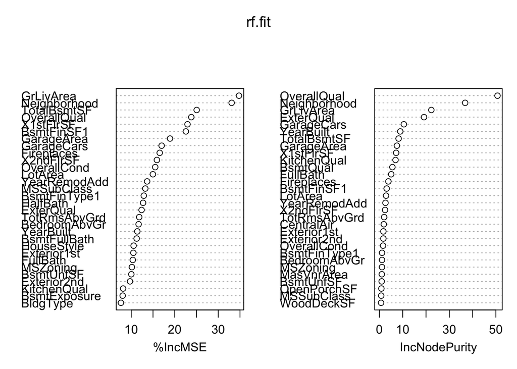

```r
varImpPlot(rf.fit)
```

### prediction

```r
rf.pred<-predict(rf.fit,newdata=whole_test.new)
# Id <- 1461:2919
# SalePrice <- exp(rf.pred)
# randomfroest <- data.frame(Id,SalePrice)
# names(randomfroest) <- c("Id","SalePrice")
# write.csv(randomfroest,"randomfroest .csv", row.names = FALSE)
```

## Boosting

```r
library(gbm)
gbm.cv.fit<-gbm(log(SalePrice)~.,data=whole_train, distribution="gaussian", shrinkage=0.01,n.tree=5000,interaction.depth=4,cv.folds=10)
gbm.cv.fit
```

```
## gbm(formula = log(SalePrice) ~ ., distribution = "gaussian",
##     data = whole_train, n.trees = 5000, interaction.depth = 4,
##     shrinkage = 0.01, cv.folds = 10)
## A gradient boosted model with gaussian loss function.
## 5000 iterations were performed.
## The best cross-validation iteration was 1192.
## There were 68 predictors of which 64 had non-zero influence.
```

### choose tuning parameter and interpretation

```r
which.min(gbm.cv.fit$cv.error)
```

```
## [1] 1192
```

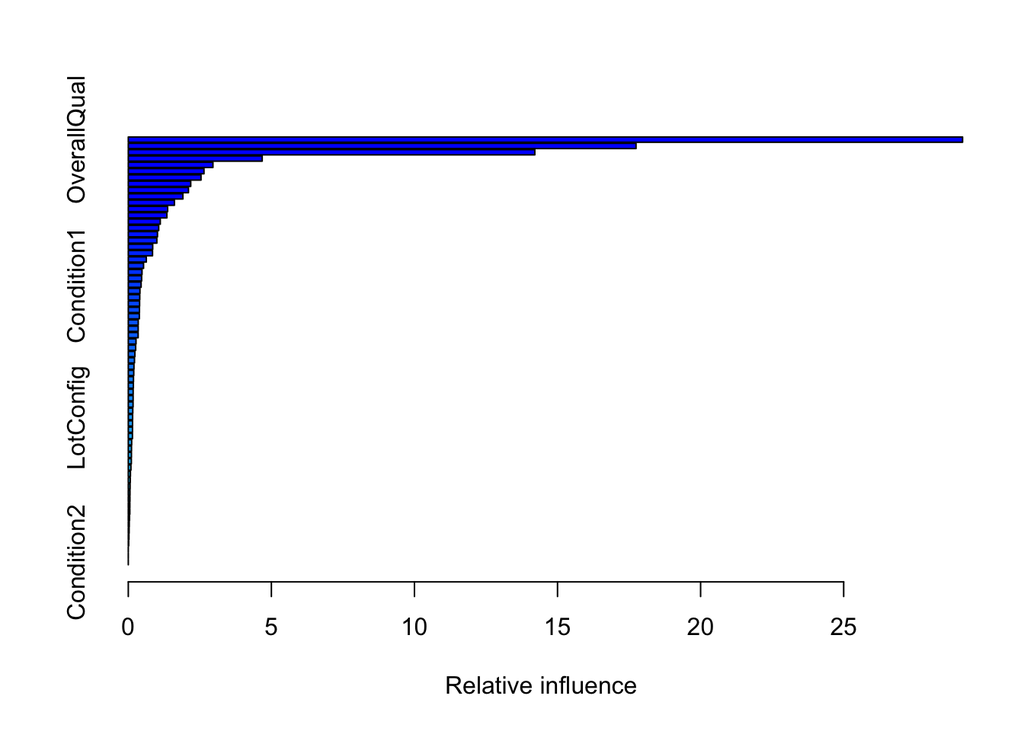

|  | var | rel.inf |
| --- | --- | --- |
| OverallQual | OverallQual | 29.15462467 |
| Neighborhood | Neighborhood | 17.74396252 |
| GrLivArea | GrLivArea | 14.20642397 |
| TotalBsmtSF | TotalBsmtSF | 4.67900621 |
| GarageArea | GarageArea | 2.95800125 |
| GarageCars | GarageCars | 2.64505035 |
| ExterQual | ExterQual | 2.54126813 |
| X1stFlrSF | X1stFlrSF | 2.18185466 |
| YearRemodAdd | YearRemodAdd | 2.10269960 |
| BsmtFinSF1 | BsmtFinSF1 | 1.90755447 |

[output cut: 58 more lines]

```r
summary(gbm.cv.fit)
```

### prediction

```r
gbm.pred<-predict(gbm.cv.fit,newdata=whole_test.new,n.trees=which.min(gbm.cv.fit$cv.error))
# Id <- 1461:2919
# SalePrice <- exp(gbm.pred)
# boosting <- data.frame(Id,SalePrice)
# names(boosting) <- c("Id","SalePrice")
# write.csv(boosting,"boosting .csv", row.names = FALSE)
```